# Session 5 — External Validation, Decision Curves and Reporting

Transportability · calibration in a new district · model comparison · recalibration · net benefit · TRIPOD · Lab 5

Community Medicine Workshop

## Where we are

- Sessions 1 to 4: build, evaluate, internally validate, shrink
- Today: the **real test**: a **different district**, 2,000 adults, **never used for fitting**
- By the end you can:
  - **validate externally** (discrimination, calibration)
  - **recalibrate** a model for a new setting
  - judge **clinical usefulness** with a **decision curve**
  - **report** with TRIPOD

# Topic 1 — Validation in a new district

## Discrimination and average calibration

```r
roc_v <- roc(val$diabetes, val$risk, quiet = TRUE)
c(auc = as.numeric(auc(roc_v)), predicted = mean(val$risk), observed = mean(val$diabetes)) |> round(3)
```

```
      auc predicted  observed
    0.709     0.179     0.246
```

```r
ci.auc(roc_v)
```

```
95% CI: 0.6823-0.7358 (DeLong)
```

**AUC 0.71** (95% CI 0.68 to 0.74): **lower** than the apparent 0.80 and the bootstrap-corrected 0.776. **Mean predicted risk 17.9%** vs **24.6% observed**: the model **under-estimates** risk in this district (older, less active, higher prevalence).

## Calibration slope and plot

```r
c(slope = coef(glm(diabetes ~ lpv, data = val, family = binomial))[["lpv"]], intercept_offset = coef(glm(diabetes ~ offset(lpv), data = val, family = binomial))[[1]]) |> round(2)
```

```
           slope intercept_offset
            0.67             0.50
```

```r
calv <- val |> mutate(decile = ntile(risk, 10)) |> group_by(decile) |> summarise(predicted = mean(risk), observed = mean(diabetes))
ggplot(calv, aes(predicted, observed)) + geom_abline(linetype = 2) + geom_point(size = 3, colour = col_red) + geom_line(colour = col_red) + coord_equal(xlim = c(0, 0.7), ylim = c(0, 0.7)) + labs(x = "Mean predicted risk", y = "Observed proportion with diabetes")
```

- **Slope 0.67**: predictions are **too extreme** (low risks too low, high risks too high): some **overfitting** and **weaker effects** in the new district
- **Intercept +0.50** (calibration-in-the-large): risk **under-estimated on average**
- Typical of **external validation**: performance **drops** and **calibration** needs updating

## Calibration slope and plot

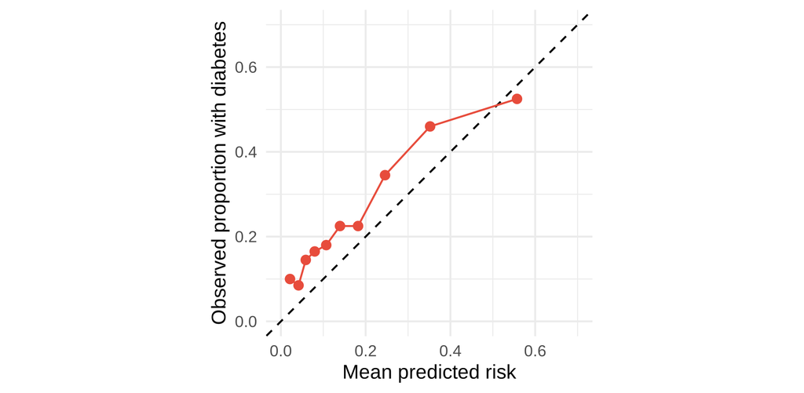

## Which development strategy transports best?

```r
slope_of <- function(lp) coef(glm(diabetes ~ lp, data = val, family = binomial))[["lp"]]
lps <- list(ML_8 = predict(m_true, val), ML_all = predict(m_all, val), ridge = as.numeric(predict(cv_r, xv_all, s = "lambda.min")), lasso = as.numeric(predict(cv_l, xv_all, s = "lambda.1se")))
sapply(lps, function(lp) c(auc = auc_of(val$diabetes, lp), slope = slope_of(lp))) |> t() |> round(2)
```

```
        auc slope
ML_8   0.71  0.67
ML_all 0.69  0.53
ridge  0.70  0.80
lasso  0.71  1.59
```

- The **all-markers** ML model is the **worst calibrated** (slope **0.53**) and has the lowest AUC (0.69)
- **Ridge**: slope **0.80**, closest to 1 among the full models
- **Lasso at λ.1se**: slope **1.59**: **over-shrunk** (too narrow)
- **No strategy fully repairs** the change of population: that needs **recalibration**

# Topic 2 — Updating and usefulness

## Recalibration

```r
rec <- glm(diabetes ~ lpv, data = val, family = binomial)
val$risk_rec <- predict(rec, type = "response")
c(brier_before = mean((val$risk - val$diabetes)^2), brier_after = mean((val$risk_rec - val$diabetes)^2)) |> round(3)
```

```
brier_before  brier_after
       0.170        0.165
```

- **Recalibrate**: re-estimate the **intercept** (and the **slope**) in the new setting; keep the predictors and relative weights
- **Brier 0.170 to 0.165**; the **AUC does not change** (only the calibration)
- Better than **refitting everything** on a small local sample (overfitting), but needs **local outcome data**
- Models need **updating over time** and across **settings**

## Decision curve: net benefit

net benefit = TP / n − FP / n × t / (1 − t) t = the risk threshold at which you would act

```r
nb <- function(risk, y, t) { tp <- sum(risk >= t & y == 1); fp <- sum(risk >= t & y == 0); tp / length(y) - fp / length(y) * t / (1 - t) }
ts <- seq(0.05, 0.40, 0.05)
tibble(threshold = ts, model = sapply(ts, \(t) nb(val$risk_rec, val$diabetes, t)), treat_all = sapply(ts, \(t) mean(val$diabetes) - (1 - mean(val$diabetes)) * t / (1 - t))) |> mutate(across(-threshold, \(x) round(x, 3)))
```

```
# A tibble: 8 × 3
  threshold model treat_all
      <dbl> <dbl>     <dbl>
1      0.05 0.206     0.206
2      0.1  0.162     0.162
3      0.15 0.126     0.112
4      0.2  0.097     0.057
5      0.25 0.074    -0.006
6      0.3  0.063    -0.078
7      0.35 0.044    -0.161
8      0.4  0.027    -0.258
```

## Reading the decision curve

**Treat none = 0.** The model has the **same** net benefit as **treat-all** up to a threshold of **10%**, and a **clearly higher** one from **15%** (0.126 vs 0.112) up to 40%, where treating everyone becomes **harmful** (negative above about 25%). A net benefit of **0.10 at 20%** is like finding **10 extra true cases per 100 adults with no unnecessary test**. **Choose the threshold from costs and benefits**, not from the AUC.

## Reporting: TRIPOD

- **Source of data**, setting, **outcome**, **predictors** and their measurement
- **Sample size** and **events**; handling of **missing data**
- The **full model** (**intercept and all coefficients**) so others can use it
- **Performance**: AUC, **calibration** (plot, slope, intercept), with CIs
- **Internal validation** (bootstrap) and **external validation**, any **updating**
- **Limitations** and intended **use** (threshold, who)

*Example:* “The model (logistic regression, 8 predictors, 84 events in 700 adults) had an apparent AUC of 0.80 (bootstrap-corrected 0.78); in an external cohort of 2,000 adults the AUC was 0.71, the calibration slope 0.67 and risk was under-estimated (mean 17.9% vs 24.6% observed).”

## 🔧 Switch to R — Lab 5

**File:** `prediction-workshop/labs/lab5_external.R`

- apply the model to the new district: AUC, calibration
- compare ML, ridge and lasso; recalibrate
- decision curve and a TRIPOD sentence

**Time:** 45 minutes · answer the Q questions in the comments

## Self-check quiz (1/5)

The AUC is 0.80 in development and 0.71 in the external cohort. What is the most likely reason?

- The external cohort is larger, and large cohorts give lower AUCs
- The model was fitted to the external cohort and is therefore too optimistic
- AUC values cannot be compared between cohorts
- A different case-mix and weaker predictor effects, plus some overfitting

## Self-check quiz (2/5)

The mean predicted risk is 17.9% and the observed risk 24.6% in the external cohort. What does this show?

- Poor calibration-in-the-large: risk is under-estimated in this district
- Poor discrimination: the model cannot rank the adults correctly
- Good calibration, because both numbers are in the same range
- Overfitting in the development data, which the calibration slope measures

## Self-check quiz (3/5)

What does an external calibration slope of 0.67 mean?

- Risks are under-estimated by 33% for all of the patients in the cohort
- Predictions are too extreme: low risks too low, high risks too high
- The model gets two thirds of the patients right in the new cohort
- The AUC is 0.67 in the validation cohort and 0.80 in development

## Self-check quiz (4/5)

What is a decision curve used for?

- To plot the ROC curves of several different cohorts together on one graph
- To find the risk threshold that gives the highest AUC for the model
- To compare the calibration slopes of competing models in one picture
- To show the net benefit of the model at different risk thresholds

## Self-check quiz (5/5)

Which item is essential in a report of a model that others will want to use?

- The full equation with the intercept, and how it was validated
- The p-value of each predictor in the final model, with its estimate
- The software code that was used to draw the ROC curve in the paper
- The name of the statistician who developed the model and their institute

## Score and take-home

**Your score:**

- **External validation** = the real test: AUC drops, calibration shifts
- Report **calibration-in-the-large**, **slope** and a **calibration plot**
- **Recalibrate** for a new setting; update over time
- **Decision curve**: net benefit at the thresholds that matter
- **TRIPOD**: full equation, performance, validation, limitations

**Next:** Cheat sheet and the next module